# My R Markdown Primer

Paul Tunceren

2026-11-15

The package I chose to utilize is called “f1dataR” which is a public data-set I found from GitHub https://github.com/SCasanova/f1dataR.git The data-set is filled with data along the lines of Formula 1 racing drivers and their racing output each week. The variables used in the data-set are “driver_id”, “constructor_id” “points”, “position”, “grid”, “laps”, “status”, “gap”,“fastest_rank”, “fastest”, “top_speed_kph” and “time_sec” just to get an idea of what collection consists of.

Below are the packages and library call I called for this document.

```r
library(f1dataR)
```

```r
library(ggplot2)
library(dplyr)
```

Now that we have our packages selected and current, we will use “load_results()” to pull from the “f1dataR” data. Below you will see the we have pulled the most “current”/“2026” season and “last”/“20” round that was raced. This function also allows for the function to utilized like the example I will display here = <f1 <-load_results(season = “current”, round = “last”)> which accepts characters or numeric input. This code would call for the most current racing results from the last known race. We then called for the head() and names() of the “f1” matrix to get a glimpse of the attached variables.

```r
f1 <-load_results(season = "2026", round = "20")
head(f1)
```

```
## # A tibble: 6 × 12
##   driver_id constructor_id points position grid  laps  status gap   fastest_rank
##   <chr>     <chr>          <chr>  <chr>    <chr> <chr> <chr>  <chr> <chr>
## 1 norris    mclaren        25     1        1     71    Finis… 1:35… 3
## 2 max_vers… red_bull       18     2        21    71    Finis… +14.… 5
## 3 hadjar    red_bull       15     3        5     71    Finis… +24.… 2
## 4 russell   mercedes       12     4        7     71    Finis… +33.… 12
## 5 antonelli mercedes       10     5        2     71    Finis… +41.… 1
## 6 piastri   mclaren        8      6        10    71    Finis… +56.… 4
## # ℹ 3 more variables: fastest <chr>, top_speed_kph <dbl>, time_sec <dbl>
```

```r
names(f1)
```

```
##  [1] "driver_id"      "constructor_id" "points"         "position"
##  [5] "grid"           "laps"           "status"         "gap"
##  [9] "fastest_rank"   "fastest"        "top_speed_kph"  "time_sec"
```

```r
f1_results <- load_results(season = "current", round = "last") %>%
  mutate(
    grid = as.numeric(grid),
    position = as.numeric(position),
    delta_p = grid - position
  )
print(f1_results[, c("driver_id", "delta_p")])
```

```
## # A tibble: 22 × 2
##    driver_id      delta_p
##    <chr>            <dbl>
##  1 norris               0
##  2 max_verstappen      19
##  3 hadjar               2
##  4 russell              3
##  5 antonelli           -3
##  6 piastri              4
##  7 lawson              -4
##  8 leclerc              6
##  9 hamilton            11
## 10 hulkenberg          -6
## # ℹ 12 more rows
```

Below, we’ve combined the “f1” data-set with the column “points” and we plot them in conjunction with “driver_id” to produce a scatter-plot using “geom_point().” The variable “points” is stored as a character in the data-set, so we use the “as.numeric” function to convert the values as numbers rather than characters to be plotted. The plot uses “driver_id” as our x-axis and “points” as our y-axis to display the amount of points each driver did, or did not collect during this race.

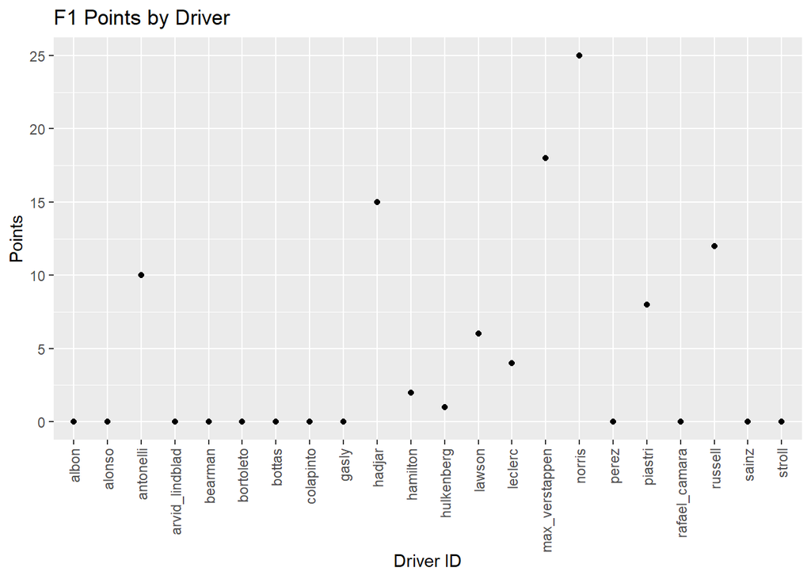

```r
f1$points <- as.numeric(f1$points)

ggplot(f1, aes(x = driver_id, y = points)) +
  geom_point() +
  theme(axis.text.x = element_text(angle = 90, vjust = 0.5, hjust = 1)) +
  labs(title = "F1 Points by Driver", x = "Driver ID", y = "Points")
```